# Analyse fichier HUS

JcB

03/10/2014

## Analyse du fichier HUS

Le fichier *RPU*670780055_141002_Hus.csv_ comporte **2094** RPU crées entre le *2014-09-25 00:05:00* et le *2014-10-01 23:52:00* soit **7** jours. Le nombre moyen de RPU créé est de 299 par jour (médiane 297 ).

## Aspect quantitatif

L’exhaustivité quantitative du fichier est excellente et sans comparaison avec les RPU habituellement transmis. Le nombre de RPU est del’ordre de 300 par jour (et par extrapolation 110.000/an) ce qui correspond à la réalité. Les heures d’entrée et de sortie sont tout à fait cohérentes ce qui donne des durées de séjour très comparables a celles des autres établissement. La mise en place du FINESS géographique permettra de séparer l’activité du NHC et de HTP. Pour HTP, l’age permet de distinguer le SU adulte du SU pédiatrique.

Le nombre de patients mineurs est de 777 (37.11 %)

##### durée de séjour (heures):

```
##    Min. 1st Qu.  Median    Mean 3rd Qu.    Max.    NA's
##    0.00    0.95    2.42    3.78    5.64   33.80       3
```

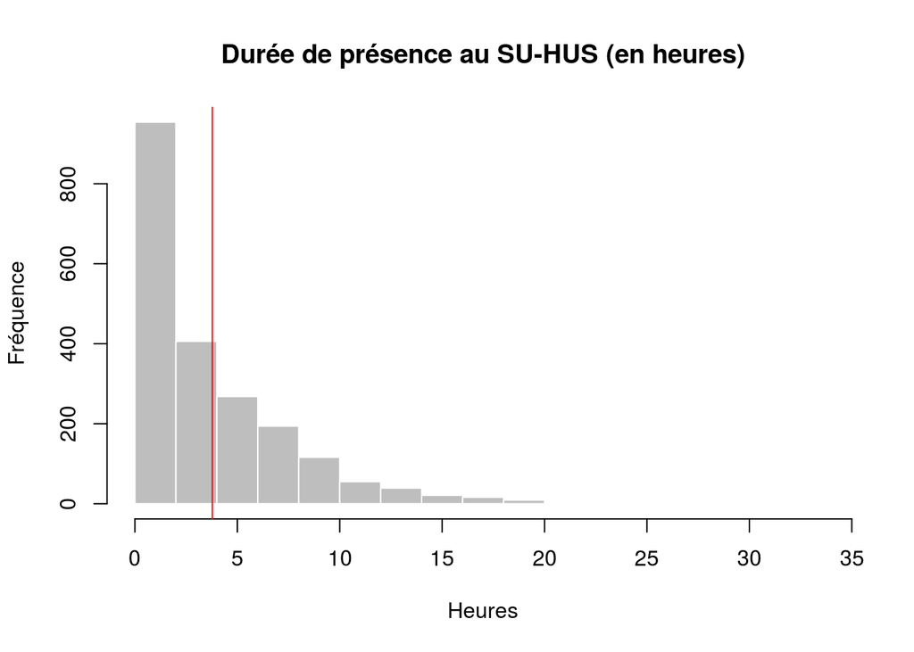

## Aspect qualitatif

#### Taux de complétude

Taux de renseignement des différents items du RPU (en % de données manquantes):

```
##            ID        FINESS   CODE_POSTAL       COMMUNE     NAISSANCE
##          0.00          0.00          0.00          0.00          0.00
##          SEXE        ENTREE   MODE_ENTREE    PROVENANCE     TRANSPORT
##          0.00          0.00          0.00         99.95         67.57
## TRANSPORT_PEC         MOTIF       GRAVITE            DP        SORTIE
##         99.09         36.68         54.11         30.90          0.14
##   MODE_SORTIE   ORIENTATION   DESTINATION      DIAG_ASS     ACTES_ASS
##         66.38         76.36         75.64          0.00          0.00
##       EXTRACT           AGE        SEJOUR
##          0.00          0.00          0.14
```

Items calculés: AGE, SEJOUR (différence SORTIE-ENTREE)

L’exhaustivité est de l’ordre de 100% pour la plupart des items “administratifs” (sexe, date de naissance, zip, commune, etc.) sauf pour MODE_SORTIE qui enregistre comment le patient est sorti du service (retour à domicile, hospitalisation, transfert, décès). Dans 66 % des cas on ne sait pas ce qu’est devenu le patient. Sans cet item, les champs ORIENTATION et DESTINATION ne peuvent être calculés correctement.

#### mode de sortie:

```
##  Mutation Transfert  Domicile     Décès      NA's
##       499        11       194         0      1390
```

```
## CHIR  MED  REA   SC   SI UHCD NA's
##  106  141   11   11   28  198 1599
```

```
##  MCO  SSR  SLD  PSY  HAD  HMS NA's
##  499    3    0    8    0    0 1584
```

#### Mode d’entrée et Provenance

```r
summary(d$MODE_ENTREE)
```

```
##  Mutation Transfert  Domicile
##         1         0      2093
```

```r
mean(is.na(d$MODE_ENTREE))
```

```
## [1] 0
```

```r
summary(d$PROVENANCE)
```

```
##  MCO  SSR  SLD  PSY  PEA  PEO NA's
##    1    0    0    0    0    0 2093
```

```r
mean(is.na(d$PROVENANCE))
```

```
## [1] 0.9995
```

#### Transport et prise en charge durant le transport

```r
summary(d$TRANSPORT)
```

```
##  AMBU    FO PERSO  SMUR  VSAB  NA's
##   347     2   118    16   196  1415
```

```r
summary(d$TRANSPORT_PEC)
```

```
##     MED PARAMED    NA's
##      11       8    2075
```

#### Gravité

```r
summary(d$GRAVITE)
```

```
##    1    2    3    4 NA's
##  460  357  143    1 1133
```

```r
mean(is.na(d$GRAVITE))
```

```
## [1] 0.5411
```

```r
summary(d$AGE)
```

```
##    Min. 1st Qu.  Median    Mean 3rd Qu.    Max.
##     0.0     9.0    27.0    34.3    56.0    97.0
```

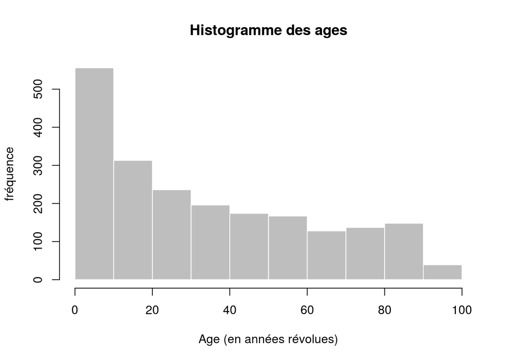

```r
hist(d$AGE, main="Histogramme des ages", xlab="Age (en années révolues)", ylab="fréquence", col="gray", border="white")
```